# Risk Factor Analysis

## Outcome Variable

**Outcome Variable:** ever_stunted

## Predictor Variables

**Intervention Variable:** perdiar24

**Adjustment Set:**

- arm
- sex
- W_birthwt
- W_birthlen
- W_nrooms
- month
- brthmon
- impfloor
- impsan
- safeh20
- delta_W_birthwt
- delta_W_birthlen
- delta_W_nrooms
- delta_month
- delta_brthmon
- delta_impfloor
- delta_impsan
- delta_safeh20

## Stratifying Variables

The analysis was stratified on these variable(s):

- agecat
- studyid
- country

## Data Summary

| agecat | studyid | country | perdiar24 | ever_stunted | n_cell | n |
| --- | --- | --- | --- | --- | --- | --- |
| 0-24 months (no birth st.) | ki0047075b-MAL-ED | BANGLADESH | 0% | 0 | 10 | 217 |
| 0-24 months (no birth st.) | ki0047075b-MAL-ED | BANGLADESH | 0% | 1 | 6 | 217 |
| 0-24 months (no birth st.) | ki0047075b-MAL-ED | BANGLADESH | (0%, 5%] | 0 | 63 | 217 |
| 0-24 months (no birth st.) | ki0047075b-MAL-ED | BANGLADESH | (0%, 5%] | 1 | 65 | 217 |
| 0-24 months (no birth st.) | ki0047075b-MAL-ED | BANGLADESH | >5% | 0 | 31 | 217 |
| 0-24 months (no birth st.) | ki0047075b-MAL-ED | BANGLADESH | >5% | 1 | 42 | 217 |
| 0-24 months (no birth st.) | ki0047075b-MAL-ED | BRAZIL | 0% | 0 | 106 | 208 |
| 0-24 months (no birth st.) | ki0047075b-MAL-ED | BRAZIL | 0% | 1 | 12 | 208 |
| 0-24 months (no birth st.) | ki0047075b-MAL-ED | BRAZIL | (0%, 5%] | 0 | 71 | 208 |
| 0-24 months (no birth st.) | ki0047075b-MAL-ED | BRAZIL | (0%, 5%] | 1 | 17 | 208 |
| 0-24 months (no birth st.) | ki0047075b-MAL-ED | BRAZIL | >5% | 0 | 2 | 208 |
| 0-24 months (no birth st.) | ki0047075b-MAL-ED | BRAZIL | >5% | 1 | 0 | 208 |
| 0-24 months (no birth st.) | ki0047075b-MAL-ED | INDIA | 0% | 0 | 9 | 209 |
| 0-24 months (no birth st.) | ki0047075b-MAL-ED | INDIA | 0% | 1 | 3 | 209 |
| 0-24 months (no birth st.) | ki0047075b-MAL-ED | INDIA | (0%, 5%] | 0 | 73 | 209 |
| 0-24 months (no birth st.) | ki0047075b-MAL-ED | INDIA | (0%, 5%] | 1 | 87 | 209 |
| 0-24 months (no birth st.) | ki0047075b-MAL-ED | INDIA | >5% | 0 | 19 | 209 |
| 0-24 months (no birth st.) | ki0047075b-MAL-ED | INDIA | >5% | 1 | 18 | 209 |
| 0-24 months (no birth st.) | ki0047075b-MAL-ED | NEPAL | 0% | 0 | 12 | 212 |
| 0-24 months (no birth st.) | ki0047075b-MAL-ED | NEPAL | 0% | 1 | 2 | 212 |
| 0-24 months (no birth st.) | ki0047075b-MAL-ED | NEPAL | (0%, 5%] | 0 | 95 | 212 |
| 0-24 months (no birth st.) | ki0047075b-MAL-ED | NEPAL | (0%, 5%] | 1 | 36 | 212 |
| 0-24 months (no birth st.) | ki0047075b-MAL-ED | NEPAL | >5% | 0 | 50 | 212 |
| 0-24 months (no birth st.) | ki0047075b-MAL-ED | NEPAL | >5% | 1 | 17 | 212 |
| 0-24 months (no birth st.) | ki0047075b-MAL-ED | PERU | 0% | 0 | 21 | 266 |
| 0-24 months (no birth st.) | ki0047075b-MAL-ED | PERU | 0% | 1 | 6 | 266 |
| 0-24 months (no birth st.) | ki0047075b-MAL-ED | PERU | (0%, 5%] | 0 | 34 | 266 |
| 0-24 months (no birth st.) | ki0047075b-MAL-ED | PERU | (0%, 5%] | 1 | 65 | 266 |
| 0-24 months (no birth st.) | ki0047075b-MAL-ED | PERU | >5% | 0 | 60 | 266 |
| 0-24 months (no birth st.) | ki0047075b-MAL-ED | PERU | >5% | 1 | 80 | 266 |

[output cut: 342 more lines]

The following strata were considered:

- agecat: 0-24 months (no birth st.), studyid: ki0047075b-MAL-ED, country: BANGLADESH
- agecat: 0-24 months (no birth st.), studyid: ki0047075b-MAL-ED, country: BRAZIL
- agecat: 0-24 months (no birth st.), studyid: ki0047075b-MAL-ED, country: INDIA
- agecat: 0-24 months (no birth st.), studyid: ki0047075b-MAL-ED, country: NEPAL
- agecat: 0-24 months (no birth st.), studyid: ki0047075b-MAL-ED, country: PERU
- agecat: 0-24 months (no birth st.), studyid: ki0047075b-MAL-ED, country: SOUTH AFRICA
- agecat: 0-24 months (no birth st.), studyid: ki0047075b-MAL-ED, country: TANZANIA, UNITED REPUBLIC OF
- agecat: 0-24 months (no birth st.), studyid: ki1000109-EE, country: PAKISTAN
- agecat: 0-24 months (no birth st.), studyid: ki1000109-ResPak, country: PAKISTAN
- agecat: 0-24 months (no birth st.), studyid: ki1000304b-SAS-FoodSuppl, country: INDIA
- agecat: 0-24 months (no birth st.), studyid: ki1017093-NIH-Birth, country: BANGLADESH
- agecat: 0-24 months (no birth st.), studyid: ki1017093b-PROVIDE, country: BANGLADESH
- agecat: 0-24 months (no birth st.), studyid: ki1017093c-NIH-Crypto, country: BANGLADESH
- agecat: 0-24 months (no birth st.), studyid: ki1112895-Guatemala BSC, country: GUATEMALA
- agecat: 0-24 months (no birth st.), studyid: ki1112895-iLiNS-Zinc, country: BURKINA FASO
- agecat: 0-24 months (no birth st.), studyid: ki1114097-CMIN, country: BANGLADESH
- agecat: 0-24 months (no birth st.), studyid: ki1114097-CMIN, country: BRAZIL
- agecat: 0-24 months (no birth st.), studyid: ki1114097-CMIN, country: GUINEA-BISSAU
- agecat: 0-24 months (no birth st.), studyid: ki1114097-CMIN, country: PERU
- agecat: 0-24 months (no birth st.), studyid: ki1114097-CONTENT, country: PERU
- agecat: 0-24 months (no birth st.), studyid: kiGH5241-JiVitA-4, country: BANGLADESH
- agecat: 0-6 months (no birth st.), studyid: ki0047075b-MAL-ED, country: BANGLADESH
- agecat: 0-6 months (no birth st.), studyid: ki0047075b-MAL-ED, country: BRAZIL
- agecat: 0-6 months (no birth st.), studyid: ki0047075b-MAL-ED, country: INDIA
- agecat: 0-6 months (no birth st.), studyid: ki0047075b-MAL-ED, country: NEPAL
- agecat: 0-6 months (no birth st.), studyid: ki0047075b-MAL-ED, country: PERU
- agecat: 0-6 months (no birth st.), studyid: ki0047075b-MAL-ED, country: SOUTH AFRICA
- agecat: 0-6 months (no birth st.), studyid: ki0047075b-MAL-ED, country: TANZANIA, UNITED REPUBLIC OF
- agecat: 0-6 months (no birth st.), studyid: ki1000109-EE, country: PAKISTAN
- agecat: 0-6 months (no birth st.), studyid: ki1000109-ResPak, country: PAKISTAN
- agecat: 0-6 months (no birth st.), studyid: ki1000304b-SAS-FoodSuppl, country: INDIA
- agecat: 0-6 months (no birth st.), studyid: ki1017093-NIH-Birth, country: BANGLADESH
- agecat: 0-6 months (no birth st.), studyid: ki1017093b-PROVIDE, country: BANGLADESH
- agecat: 0-6 months (no birth st.), studyid: ki1017093c-NIH-Crypto, country: BANGLADESH
- agecat: 0-6 months (no birth st.), studyid: ki1112895-Guatemala BSC, country: GUATEMALA
- agecat: 0-6 months (no birth st.), studyid: ki1114097-CMIN, country: BANGLADESH
- agecat: 0-6 months (no birth st.), studyid: ki1114097-CMIN, country: BRAZIL
- agecat: 0-6 months (no birth st.), studyid: ki1114097-CMIN, country: GUINEA-BISSAU
- agecat: 0-6 months (no birth st.), studyid: ki1114097-CMIN, country: PERU
- agecat: 0-6 months (no birth st.), studyid: ki1114097-CONTENT, country: PERU
- agecat: 0-6 months (no birth st.), studyid: kiGH5241-JiVitA-4, country: BANGLADESH
- agecat: 6-24 months, studyid: ki0047075b-MAL-ED, country: BANGLADESH
- agecat: 6-24 months, studyid: ki0047075b-MAL-ED, country: BRAZIL
- agecat: 6-24 months, studyid: ki0047075b-MAL-ED, country: INDIA
- agecat: 6-24 months, studyid: ki0047075b-MAL-ED, country: NEPAL
- agecat: 6-24 months, studyid: ki0047075b-MAL-ED, country: PERU
- agecat: 6-24 months, studyid: ki0047075b-MAL-ED, country: SOUTH AFRICA
- agecat: 6-24 months, studyid: ki0047075b-MAL-ED, country: TANZANIA, UNITED REPUBLIC OF
- agecat: 6-24 months, studyid: ki1000109-EE, country: PAKISTAN
- agecat: 6-24 months, studyid: ki1000109-ResPak, country: PAKISTAN
- agecat: 6-24 months, studyid: ki1000304b-SAS-FoodSuppl, country: INDIA
- agecat: 6-24 months, studyid: ki1017093-NIH-Birth, country: BANGLADESH
- agecat: 6-24 months, studyid: ki1017093b-PROVIDE, country: BANGLADESH
- agecat: 6-24 months, studyid: ki1017093c-NIH-Crypto, country: BANGLADESH
- agecat: 6-24 months, studyid: ki1112895-Guatemala BSC, country: GUATEMALA
- agecat: 6-24 months, studyid: ki1112895-iLiNS-Zinc, country: BURKINA FASO
- agecat: 6-24 months, studyid: ki1114097-CMIN, country: BANGLADESH
- agecat: 6-24 months, studyid: ki1114097-CMIN, country: BRAZIL
- agecat: 6-24 months, studyid: ki1114097-CMIN, country: GUINEA-BISSAU
- agecat: 6-24 months, studyid: ki1114097-CMIN, country: PERU
- agecat: 6-24 months, studyid: ki1114097-CONTENT, country: PERU
- agecat: 6-24 months, studyid: kiGH5241-JiVitA-4, country: BANGLADESH

### Dropped Strata

Some strata were dropped due to rare outcomes:

- agecat: 0-24 months (no birth st.), studyid: ki0047075b-MAL-ED, country: BRAZIL
- agecat: 0-24 months (no birth st.), studyid: ki0047075b-MAL-ED, country: INDIA
- agecat: 0-24 months (no birth st.), studyid: ki0047075b-MAL-ED, country: NEPAL
- agecat: 0-24 months (no birth st.), studyid: ki0047075b-MAL-ED, country: SOUTH AFRICA
- agecat: 0-24 months (no birth st.), studyid: ki1000109-EE, country: PAKISTAN
- agecat: 0-24 months (no birth st.), studyid: ki1017093b-PROVIDE, country: BANGLADESH
- agecat: 0-24 months (no birth st.), studyid: ki1114097-CMIN, country: BANGLADESH
- agecat: 0-24 months (no birth st.), studyid: ki1114097-CMIN, country: BRAZIL
- agecat: 0-24 months (no birth st.), studyid: ki1114097-CONTENT, country: PERU
- agecat: 0-6 months (no birth st.), studyid: ki0047075b-MAL-ED, country: BANGLADESH
- agecat: 0-6 months (no birth st.), studyid: ki0047075b-MAL-ED, country: BRAZIL
- agecat: 0-6 months (no birth st.), studyid: ki0047075b-MAL-ED, country: INDIA
- agecat: 0-6 months (no birth st.), studyid: ki0047075b-MAL-ED, country: NEPAL
- agecat: 0-6 months (no birth st.), studyid: ki0047075b-MAL-ED, country: SOUTH AFRICA
- agecat: 0-6 months (no birth st.), studyid: ki0047075b-MAL-ED, country: TANZANIA, UNITED REPUBLIC OF
- agecat: 0-6 months (no birth st.), studyid: ki1000304b-SAS-FoodSuppl, country: INDIA
- agecat: 0-6 months (no birth st.), studyid: ki1017093-NIH-Birth, country: BANGLADESH
- agecat: 0-6 months (no birth st.), studyid: ki1017093b-PROVIDE, country: BANGLADESH
- agecat: 0-6 months (no birth st.), studyid: ki1112895-Guatemala BSC, country: GUATEMALA
- agecat: 0-6 months (no birth st.), studyid: ki1114097-CMIN, country: BANGLADESH
- agecat: 0-6 months (no birth st.), studyid: ki1114097-CMIN, country: BRAZIL
- agecat: 0-6 months (no birth st.), studyid: ki1114097-CMIN, country: GUINEA-BISSAU
- agecat: 0-6 months (no birth st.), studyid: ki1114097-CMIN, country: PERU
- agecat: 0-6 months (no birth st.), studyid: ki1114097-CONTENT, country: PERU
- agecat: 6-24 months, studyid: ki0047075b-MAL-ED, country: BANGLADESH
- agecat: 6-24 months, studyid: ki0047075b-MAL-ED, country: BRAZIL
- agecat: 6-24 months, studyid: ki0047075b-MAL-ED, country: INDIA
- agecat: 6-24 months, studyid: ki0047075b-MAL-ED, country: NEPAL
- agecat: 6-24 months, studyid: ki0047075b-MAL-ED, country: PERU
- agecat: 6-24 months, studyid: ki0047075b-MAL-ED, country: SOUTH AFRICA
- agecat: 6-24 months, studyid: ki0047075b-MAL-ED, country: TANZANIA, UNITED REPUBLIC OF
- agecat: 6-24 months, studyid: ki1000109-EE, country: PAKISTAN
- agecat: 6-24 months, studyid: ki1000109-ResPak, country: PAKISTAN
- agecat: 6-24 months, studyid: ki1017093-NIH-Birth, country: BANGLADESH
- agecat: 6-24 months, studyid: ki1017093b-PROVIDE, country: BANGLADESH
- agecat: 6-24 months, studyid: ki1112895-Guatemala BSC, country: GUATEMALA
- agecat: 6-24 months, studyid: ki1114097-CMIN, country: BANGLADESH
- agecat: 6-24 months, studyid: ki1114097-CMIN, country: BRAZIL
- agecat: 6-24 months, studyid: ki1114097-CONTENT, country: PERU

## Methods Detail

We’re interested in the causal parameters $E[Y_a]$ for all values of $a \in \mathcal{A}$. These parameters represent the mean outcome if, possibly contrary to fact, we intervened to set all units to have $A=a$. Under the randomization and positivity assumptions, these are identified by the statistical parameters $\psi_a=E_W[E_{Y|A,W}(Y|A=a,W)]$. In addition, we’re interested in the mean of $Y$, $E[Y]$ under no intervention (the observed mean). We will estimate these parameters by using SuperLearner to fit the relevant likelihood factors – $E_{Y|A,W}(Y|A=a,W)$ and $p(A=a|W)$, and then updating our likelihood fit using a joint TMLE.

For unadjusted analyses ($W=\{\}$), initial likelihoods were estimated using Lrnr_glm to estimate the simple $E(Y|A)$ and Lrnr_mean to estimate $p(A)$. For adjusted analyses, a small library containing Lrnr_glmnet, Lrnr_xgboost, and Lrnr_mean was used.

Having estimated these parameters, we will then use the delta method to estimate relative risks and attributable risks relative to a prespecified baseline level of $A$.

# Results Detail

## Results Plots

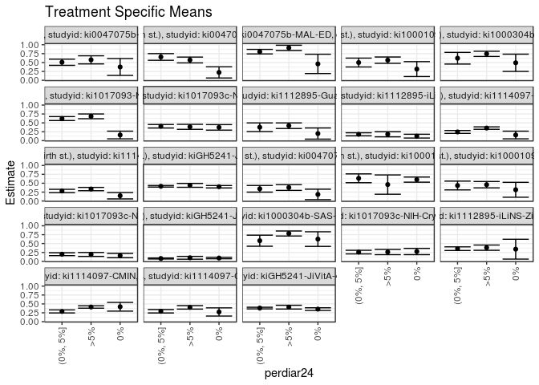

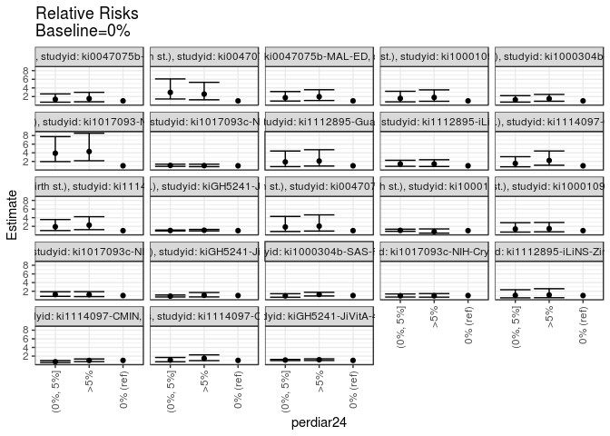

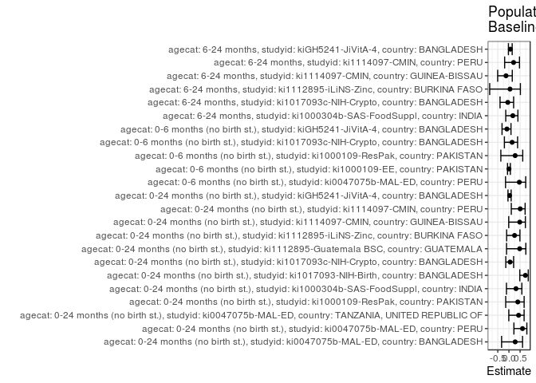

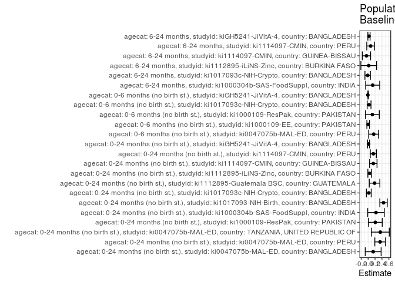

## Results Table

### Parameter: TSM

| agecat | studyid | country | intervention_level | baseline_level | estimate | ci_lower | ci_upper |
| --- | --- | --- | --- | --- | --- | --- | --- |
| 0-24 months (no birth st.) | ki0047075b-MAL-ED | BANGLADESH | 0% | NA | 0.3750000 | 0.1372357 | 0.6127643 |
| 0-24 months (no birth st.) | ki0047075b-MAL-ED | BANGLADESH | (0%, 5%] | NA | 0.5078125 | 0.4210038 | 0.5946212 |
| 0-24 months (no birth st.) | ki0047075b-MAL-ED | BANGLADESH | >5% | NA | 0.5753425 | 0.4616917 | 0.6889932 |
| 0-24 months (no birth st.) | ki0047075b-MAL-ED | PERU | 0% | NA | 0.2222222 | 0.0651116 | 0.3793329 |
| 0-24 months (no birth st.) | ki0047075b-MAL-ED | PERU | (0%, 5%] | NA | 0.6565657 | 0.5628506 | 0.7502807 |
| 0-24 months (no birth st.) | ki0047075b-MAL-ED | PERU | >5% | NA | 0.5714286 | 0.4892999 | 0.6535572 |
| 0-24 months (no birth st.) | ki0047075b-MAL-ED | TANZANIA, UNITED REPUBLIC OF | 0% | NA | 0.4615385 | 0.1899249 | 0.7331521 |
| 0-24 months (no birth st.) | ki0047075b-MAL-ED | TANZANIA, UNITED REPUBLIC OF | (0%, 5%] | NA | 0.8053691 | 0.7416526 | 0.8690857 |
| 0-24 months (no birth st.) | ki0047075b-MAL-ED | TANZANIA, UNITED REPUBLIC OF | >5% | NA | 0.9122807 | 0.8386742 | 0.9858872 |
| 0-24 months (no birth st.) | ki1000109-ResPak | PAKISTAN | 0% | NA | 0.3157895 | 0.1062586 | 0.5253203 |
| 0-24 months (no birth st.) | ki1000109-ResPak | PAKISTAN | (0%, 5%] | NA | 0.5000000 | 0.3752314 | 0.6247686 |
| 0-24 months (no birth st.) | ki1000109-ResPak | PAKISTAN | >5% | NA | 0.5666667 | 0.4777843 | 0.6555490 |
| 0-24 months (no birth st.) | ki1000304b-SAS-FoodSuppl | INDIA | 0% | NA | 0.4923852 | 0.2498742 | 0.7348963 |
| 0-24 months (no birth st.) | ki1000304b-SAS-FoodSuppl | INDIA | (0%, 5%] | NA | 0.6210469 | 0.4568739 | 0.7852199 |
| 0-24 months (no birth st.) | ki1000304b-SAS-FoodSuppl | INDIA | >5% | NA | 0.7442070 | 0.6712835 | 0.8171306 |
| 0-24 months (no birth st.) | ki1017093-NIH-Birth | BANGLADESH | 0% | NA | 0.1590909 | 0.0509150 | 0.2672668 |
| 0-24 months (no birth st.) | ki1017093-NIH-Birth | BANGLADESH | (0%, 5%] | NA | 0.6208054 | 0.5656662 | 0.6759446 |
| 0-24 months (no birth st.) | ki1017093-NIH-Birth | BANGLADESH | >5% | NA | 0.6827957 | 0.6158507 | 0.7497407 |
| 0-24 months (no birth st.) | ki1017093c-NIH-Crypto | BANGLADESH | 0% | NA | 0.3739058 | 0.2964893 | 0.4513224 |
| 0-24 months (no birth st.) | ki1017093c-NIH-Crypto | BANGLADESH | (0%, 5%] | NA | 0.4047267 | 0.3553079 | 0.4541456 |
| 0-24 months (no birth st.) | ki1017093c-NIH-Crypto | BANGLADESH | >5% | NA | 0.3884064 | 0.3182648 | 0.4585480 |
| 0-24 months (no birth st.) | ki1112895-Guatemala BSC | GUATEMALA | 0% | NA | 0.2000000 | 0.0428696 | 0.3571304 |
| 0-24 months (no birth st.) | ki1112895-Guatemala BSC | GUATEMALA | (0%, 5%] | NA | 0.3770492 | 0.2551696 | 0.4989288 |
| 0-24 months (no birth st.) | ki1112895-Guatemala BSC | GUATEMALA | >5% | NA | 0.4200000 | 0.3408478 | 0.4991522 |
| 0-24 months (no birth st.) | ki1112895-iLiNS-Zinc | BURKINA FASO | 0% | NA | 0.1269730 | 0.0736061 | 0.1803399 |
| 0-24 months (no birth st.) | ki1112895-iLiNS-Zinc | BURKINA FASO | (0%, 5%] | NA | 0.1788808 | 0.1359376 | 0.2218240 |
| 0-24 months (no birth st.) | ki1112895-iLiNS-Zinc | BURKINA FASO | >5% | NA | 0.1789875 | 0.1075184 | 0.2504566 |
| 0-24 months (no birth st.) | ki1114097-CMIN | GUINEA-BISSAU | 0% | NA | 0.1590909 | 0.0509733 | 0.2672085 |
| 0-24 months (no birth st.) | ki1114097-CMIN | GUINEA-BISSAU | (0%, 5%] | NA | 0.2447552 | 0.2040541 | 0.2854564 |
| 0-24 months (no birth st.) | ki1114097-CMIN | GUINEA-BISSAU | >5% | NA | 0.3537234 | 0.3195367 | 0.3879101 |
| 0-24 months (no birth st.) | ki1114097-CMIN | PERU | 0% | NA | 0.1475410 | 0.0584883 | 0.2365936 |
| 0-24 months (no birth st.) | ki1114097-CMIN | PERU | (0%, 5%] | NA | 0.2812500 | 0.2342517 | 0.3282483 |
| 0-24 months (no birth st.) | ki1114097-CMIN | PERU | >5% | NA | 0.3358974 | 0.2889937 | 0.3828012 |
| 0-24 months (no birth st.) | kiGH5241-JiVitA-4 | BANGLADESH | 0% | NA | 0.4010213 | 0.3664981 | 0.4355444 |
| 0-24 months (no birth st.) | kiGH5241-JiVitA-4 | BANGLADESH | (0%, 5%] | NA | 0.4144389 | 0.3924381 | 0.4364396 |
| 0-24 months (no birth st.) | kiGH5241-JiVitA-4 | BANGLADESH | >5% | NA | 0.4400105 | 0.3856692 | 0.4943518 |
| 0-6 months (no birth st.) | ki0047075b-MAL-ED | PERU | 0% | NA | 0.1851852 | 0.0383884 | 0.3319820 |
| 0-6 months (no birth st.) | ki0047075b-MAL-ED | PERU | (0%, 5%] | NA | 0.3434343 | 0.2497193 | 0.4371494 |
| 0-6 months (no birth st.) | ki0047075b-MAL-ED | PERU | >5% | NA | 0.3785714 | 0.2980760 | 0.4590669 |
| 0-6 months (no birth st.) | ki1000109-EE | PAKISTAN | 0% | NA | 0.6011236 | 0.5290439 | 0.6732033 |
| 0-6 months (no birth st.) | ki1000109-EE | PAKISTAN | (0%, 5%] | NA | 0.6379310 | 0.5139970 | 0.7618650 |
| 0-6 months (no birth st.) | ki1000109-EE | PAKISTAN | >5% | NA | 0.4615385 | 0.1899999 | 0.7330770 |
| 0-6 months (no birth st.) | ki1000109-ResPak | PAKISTAN | 0% | NA | 0.3157895 | 0.1062586 | 0.5253203 |
| 0-6 months (no birth st.) | ki1000109-ResPak | PAKISTAN | (0%, 5%] | NA | 0.4354839 | 0.3117583 | 0.5592094 |
| 0-6 months (no birth st.) | ki1000109-ResPak | PAKISTAN | >5% | NA | 0.4583333 | 0.3689622 | 0.5477045 |
| 0-6 months (no birth st.) | ki1017093c-NIH-Crypto | BANGLADESH | 0% | NA | 0.1629451 | 0.1012406 | 0.2246496 |
| 0-6 months (no birth st.) | ki1017093c-NIH-Crypto | BANGLADESH | (0%, 5%] | NA | 0.2009399 | 0.1607505 | 0.2411294 |
| 0-6 months (no birth st.) | ki1017093c-NIH-Crypto | BANGLADESH | >5% | NA | 0.1943735 | 0.1393165 | 0.2494304 |
| 0-6 months (no birth st.) | kiGH5241-JiVitA-4 | BANGLADESH | 0% | NA | 0.0933003 | 0.0723698 | 0.1142307 |
| 0-6 months (no birth st.) | kiGH5241-JiVitA-4 | BANGLADESH | (0%, 5%] | NA | 0.0803700 | 0.0669523 | 0.0937876 |
| 0-6 months (no birth st.) | kiGH5241-JiVitA-4 | BANGLADESH | >5% | NA | 0.1002113 | 0.0604838 | 0.1399389 |
| 6-24 months | ki1000304b-SAS-FoodSuppl | INDIA | 0% | NA | 0.6258188 | 0.4201469 | 0.8314907 |
| 6-24 months | ki1000304b-SAS-FoodSuppl | INDIA | (0%, 5%] | NA | 0.5800939 | 0.4245164 | 0.7356714 |
| 6-24 months | ki1000304b-SAS-FoodSuppl | INDIA | >5% | NA | 0.7828623 | 0.7126856 | 0.8530390 |
| 6-24 months | ki1017093c-NIH-Crypto | BANGLADESH | 0% | NA | 0.2764641 | 0.1884129 | 0.3645153 |
| 6-24 months | ki1017093c-NIH-Crypto | BANGLADESH | (0%, 5%] | NA | 0.2599978 | 0.2085214 | 0.3114741 |
| 6-24 months | ki1017093c-NIH-Crypto | BANGLADESH | >5% | NA | 0.2616002 | 0.1877638 | 0.3354366 |
| 6-24 months | ki1112895-iLiNS-Zinc | BURKINA FASO | 0% | NA | 0.3421363 | 0.0635417 | 0.6207309 |
| 6-24 months | ki1112895-iLiNS-Zinc | BURKINA FASO | (0%, 5%] | NA | 0.3563226 | 0.3052103 | 0.4074349 |
| 6-24 months | ki1112895-iLiNS-Zinc | BURKINA FASO | >5% | NA | 0.3843848 | 0.3101924 | 0.4585772 |
| 6-24 months | ki1114097-CMIN | GUINEA-BISSAU | 0% | NA | 0.4193652 | 0.2970688 | 0.5416616 |
| 6-24 months | ki1114097-CMIN | GUINEA-BISSAU | (0%, 5%] | NA | 0.2883040 | 0.2457256 | 0.3308824 |
| 6-24 months | ki1114097-CMIN | GUINEA-BISSAU | >5% | NA | 0.4128757 | 0.3790529 | 0.4466986 |
| 6-24 months | ki1114097-CMIN | PERU | 0% | NA | 0.2734991 | 0.1584577 | 0.3885405 |
| 6-24 months | ki1114097-CMIN | PERU | (0%, 5%] | NA | 0.2931203 | 0.2449989 | 0.3412416 |
| 6-24 months | ki1114097-CMIN | PERU | >5% | NA | 0.4022851 | 0.3535967 | 0.4509734 |
| 6-24 months | kiGH5241-JiVitA-4 | BANGLADESH | 0% | NA | 0.3535161 | 0.3161211 | 0.3909110 |
| 6-24 months | kiGH5241-JiVitA-4 | BANGLADESH | (0%, 5%] | NA | 0.3828754 | 0.3599658 | 0.4057850 |
| 6-24 months | kiGH5241-JiVitA-4 | BANGLADESH | >5% | NA | 0.4085451 | 0.3557378 | 0.4613525 |

### Parameter: E(Y)

| agecat | studyid | country | intervention_level | baseline_level | estimate | ci_lower | ci_upper |
| --- | --- | --- | --- | --- | --- | --- | --- |
| 0-24 months (no birth st.) | ki0047075b-MAL-ED | BANGLADESH | NA | NA | 0.5207373 | 0.4541154 | 0.5873593 |
| 0-24 months (no birth st.) | ki0047075b-MAL-ED | PERU | NA | NA | 0.5676692 | 0.5080232 | 0.6273151 |
| 0-24 months (no birth st.) | ki0047075b-MAL-ED | TANZANIA, UNITED REPUBLIC OF | NA | NA | 0.8127854 | 0.7610035 | 0.8645672 |
| 0-24 months (no birth st.) | ki1000109-ResPak | PAKISTAN | NA | NA | 0.5223881 | 0.4531624 | 0.5916138 |
| 0-24 months (no birth st.) | ki1000304b-SAS-FoodSuppl | INDIA | NA | NA | 0.7198444 | 0.6648337 | 0.7748550 |
| 0-24 months (no birth st.) | ki1017093-NIH-Birth | BANGLADESH | NA | NA | 0.6041667 | 0.5624147 | 0.6459187 |
| 0-24 months (no birth st.) | ki1017093c-NIH-Crypto | BANGLADESH | NA | NA | 0.3935681 | 0.3560687 | 0.4310676 |
| 0-24 months (no birth st.) | ki1112895-Guatemala BSC | GUATEMALA | NA | NA | 0.3855932 | 0.3233622 | 0.4478242 |
| 0-24 months (no birth st.) | ki1112895-iLiNS-Zinc | BURKINA FASO | NA | NA | 0.1696617 | 0.1377362 | 0.2015872 |
| 0-24 months (no birth st.) | ki1114097-CMIN | GUINEA-BISSAU | NA | NA | 0.3085714 | 0.2826947 | 0.3344481 |
| 0-24 months (no birth st.) | ki1114097-CMIN | PERU | NA | NA | 0.2976339 | 0.2659904 | 0.3292773 |
| 0-24 months (no birth st.) | kiGH5241-JiVitA-4 | BANGLADESH | NA | NA | 0.4135358 | 0.3953404 | 0.4317312 |
| 0-6 months (no birth st.) | ki0047075b-MAL-ED | PERU | NA | NA | 0.3458647 | 0.2885967 | 0.4031327 |
| 0-6 months (no birth st.) | ki1000109-EE | PAKISTAN | NA | NA | 0.6024096 | 0.5415000 | 0.6633193 |
| 0-6 months (no birth st.) | ki1000109-ResPak | PAKISTAN | NA | NA | 0.4378109 | 0.3690538 | 0.5065681 |
| 0-6 months (no birth st.) | ki1017093c-NIH-Crypto | BANGLADESH | NA | NA | 0.1898928 | 0.1597870 | 0.2199986 |
| 0-6 months (no birth st.) | kiGH5241-JiVitA-4 | BANGLADESH | NA | NA | 0.0855425 | 0.0741829 | 0.0969021 |
| 6-24 months | ki1000304b-SAS-FoodSuppl | INDIA | NA | NA | 0.7572016 | 0.7031798 | 0.8112234 |
| 6-24 months | ki1017093c-NIH-Crypto | BANGLADESH | NA | NA | 0.2628458 | 0.2244546 | 0.3012371 |
| 6-24 months | ki1112895-iLiNS-Zinc | BURKINA FASO | NA | NA | 0.3592985 | 0.2940547 | 0.4245424 |
| 6-24 months | ki1114097-CMIN | GUINEA-BISSAU | NA | NA | 0.3706505 | 0.3446055 | 0.3966956 |
| 6-24 months | ki1114097-CMIN | PERU | NA | NA | 0.3450439 | 0.3120195 | 0.3780683 |
| 6-24 months | kiGH5241-JiVitA-4 | BANGLADESH | NA | NA | 0.3779118 | 0.3593176 | 0.3965059 |

### Parameter: RR

| agecat | studyid | country | intervention_level | baseline_level | estimate | ci_lower | ci_upper |
| --- | --- | --- | --- | --- | --- | --- | --- |
| 0-24 months (no birth st.) | ki0047075b-MAL-ED | BANGLADESH | 0% | 0% | 1.0000000 | 1.0000000 | 1.0000000 |
| 0-24 months (no birth st.) | ki0047075b-MAL-ED | BANGLADESH | (0%, 5%] | 0% | 1.3541667 | 0.7022312 | 2.6113443 |
| 0-24 months (no birth st.) | ki0047075b-MAL-ED | BANGLADESH | >5% | 0% | 1.5342466 | 0.7897352 | 2.9806354 |
| 0-24 months (no birth st.) | ki0047075b-MAL-ED | PERU | 0% | 0% | 1.0000000 | 1.0000000 | 1.0000000 |
| 0-24 months (no birth st.) | ki0047075b-MAL-ED | PERU | (0%, 5%] | 0% | 2.9545455 | 1.4363174 | 6.0775834 |
| 0-24 months (no birth st.) | ki0047075b-MAL-ED | PERU | >5% | 0% | 2.5714286 | 1.2498240 | 5.2905409 |
| 0-24 months (no birth st.) | ki0047075b-MAL-ED | TANZANIA, UNITED REPUBLIC OF | 0% | 0% | 1.0000000 | 1.0000000 | 1.0000000 |
| 0-24 months (no birth st.) | ki0047075b-MAL-ED | TANZANIA, UNITED REPUBLIC OF | (0%, 5%] | 0% | 1.7449664 | 0.9636232 | 3.1598532 |
| 0-24 months (no birth st.) | ki0047075b-MAL-ED | TANZANIA, UNITED REPUBLIC OF | >5% | 0% | 1.9766082 | 1.0913124 | 3.5800749 |
| 0-24 months (no birth st.) | ki1000109-ResPak | PAKISTAN | 0% | 0% | 1.0000000 | 1.0000000 | 1.0000000 |
| 0-24 months (no birth st.) | ki1000109-ResPak | PAKISTAN | (0%, 5%] | 0% | 1.5833333 | 0.7793038 | 3.2169025 |
| 0-24 months (no birth st.) | ki1000109-ResPak | PAKISTAN | >5% | 0% | 1.7944444 | 0.9074595 | 3.5484017 |
| 0-24 months (no birth st.) | ki1000304b-SAS-FoodSuppl | INDIA | 0% | 0% | 1.0000000 | 1.0000000 | 1.0000000 |
| 0-24 months (no birth st.) | ki1000304b-SAS-FoodSuppl | INDIA | (0%, 5%] | 0% | 1.2613028 | 0.7205550 | 2.2078605 |
| 0-24 months (no birth st.) | ki1000304b-SAS-FoodSuppl | INDIA | >5% | 0% | 1.5114324 | 0.9156666 | 2.4948252 |
| 0-24 months (no birth st.) | ki1017093-NIH-Birth | BANGLADESH | 0% | 0% | 1.0000000 | 1.0000000 | 1.0000000 |
| 0-24 months (no birth st.) | ki1017093-NIH-Birth | BANGLADESH | (0%, 5%] | 0% | 3.9022052 | 1.9656098 | 7.7468099 |
| 0-24 months (no birth st.) | ki1017093-NIH-Birth | BANGLADESH | >5% | 0% | 4.2918587 | 2.1591716 | 8.5310733 |
| 0-24 months (no birth st.) | ki1017093c-NIH-Crypto | BANGLADESH | 0% | 0% | 1.0000000 | 1.0000000 | 1.0000000 |
| 0-24 months (no birth st.) | ki1017093c-NIH-Crypto | BANGLADESH | (0%, 5%] | 0% | 1.0824296 | 0.8570126 | 1.3671371 |
| 0-24 months (no birth st.) | ki1017093c-NIH-Crypto | BANGLADESH | >5% | 0% | 1.0387813 | 0.7934651 | 1.3599421 |
| 0-24 months (no birth st.) | ki1112895-Guatemala BSC | GUATEMALA | 0% | 0% | 1.0000000 | 1.0000000 | 1.0000000 |
| 0-24 months (no birth st.) | ki1112895-Guatemala BSC | GUATEMALA | (0%, 5%] | 0% | 1.8852459 | 0.8061442 | 4.4088294 |
| 0-24 months (no birth st.) | ki1112895-Guatemala BSC | GUATEMALA | >5% | 0% | 2.1000000 | 0.9361295 | 4.7108869 |
| 0-24 months (no birth st.) | ki1112895-iLiNS-Zinc | BURKINA FASO | 0% | 0% | 1.0000000 | 1.0000000 | 1.0000000 |
| 0-24 months (no birth st.) | ki1112895-iLiNS-Zinc | BURKINA FASO | (0%, 5%] | 0% | 1.4088093 | 0.8747786 | 2.2688526 |
| 0-24 months (no birth st.) | ki1112895-iLiNS-Zinc | BURKINA FASO | >5% | 0% | 1.4096497 | 0.8304919 | 2.3926933 |
| 0-24 months (no birth st.) | ki1114097-CMIN | GUINEA-BISSAU | 0% | 0% | 1.0000000 | 1.0000000 | 1.0000000 |
| 0-24 months (no birth st.) | ki1114097-CMIN | GUINEA-BISSAU | (0%, 5%] | 0% | 1.5384615 | 0.7642479 | 3.0969843 |
| 0-24 months (no birth st.) | ki1114097-CMIN | GUINEA-BISSAU | >5% | 0% | 2.2234043 | 1.1191901 | 4.4170569 |
| 0-24 months (no birth st.) | ki1114097-CMIN | PERU | 0% | 0% | 1.0000000 | 1.0000000 | 1.0000000 |
| 0-24 months (no birth st.) | ki1114097-CMIN | PERU | (0%, 5%] | 0% | 1.9062500 | 1.0190326 | 3.5659202 |
| 0-24 months (no birth st.) | ki1114097-CMIN | PERU | >5% | 0% | 2.2766382 | 1.2252917 | 4.2300796 |
| 0-24 months (no birth st.) | kiGH5241-JiVitA-4 | BANGLADESH | 0% | 0% | 1.0000000 | 1.0000000 | 1.0000000 |
| 0-24 months (no birth st.) | kiGH5241-JiVitA-4 | BANGLADESH | (0%, 5%] | 0% | 1.0334586 | 0.9363163 | 1.1406794 |
| 0-24 months (no birth st.) | kiGH5241-JiVitA-4 | BANGLADESH | >5% | 0% | 1.0972248 | 0.9412706 | 1.2790183 |
| 0-6 months (no birth st.) | ki0047075b-MAL-ED | PERU | 0% | 0% | 1.0000000 | 1.0000000 | 1.0000000 |
| 0-6 months (no birth st.) | ki0047075b-MAL-ED | PERU | (0%, 5%] | 0% | 1.8545455 | 0.8019448 | 4.2887474 |
| 0-6 months (no birth st.) | ki0047075b-MAL-ED | PERU | >5% | 0% | 2.0442857 | 0.8997158 | 4.6449157 |
| 0-6 months (no birth st.) | ki1000109-EE | PAKISTAN | 0% | 0% | 1.0000000 | 1.0000000 | 1.0000000 |
| 0-6 months (no birth st.) | ki1000109-EE | PAKISTAN | (0%, 5%] | 0% | 1.0612311 | 0.8446187 | 1.3333963 |
| 0-6 months (no birth st.) | ki1000109-EE | PAKISTAN | >5% | 0% | 0.7677930 | 0.4211932 | 1.3996096 |
| 0-6 months (no birth st.) | ki1000109-ResPak | PAKISTAN | 0% | 0% | 1.0000000 | 1.0000000 | 1.0000000 |
| 0-6 months (no birth st.) | ki1000109-ResPak | PAKISTAN | (0%, 5%] | 0% | 1.3790323 | 0.6700515 | 2.8381847 |
| 0-6 months (no birth st.) | ki1000109-ResPak | PAKISTAN | >5% | 0% | 1.4513889 | 0.7268378 | 2.8982117 |
| 0-6 months (no birth st.) | ki1017093c-NIH-Crypto | BANGLADESH | 0% | 0% | 1.0000000 | 1.0000000 | 1.0000000 |
| 0-6 months (no birth st.) | ki1017093c-NIH-Crypto | BANGLADESH | (0%, 5%] | 0% | 1.2331756 | 0.8099468 | 1.8775578 |
| 0-6 months (no birth st.) | ki1017093c-NIH-Crypto | BANGLADESH | >5% | 0% | 1.1928770 | 0.7502104 | 1.8967419 |
| 0-6 months (no birth st.) | kiGH5241-JiVitA-4 | BANGLADESH | 0% | 0% | 1.0000000 | 1.0000000 | 1.0000000 |
| 0-6 months (no birth st.) | kiGH5241-JiVitA-4 | BANGLADESH | (0%, 5%] | 0% | 0.8614120 | 0.6641400 | 1.1172804 |
| 0-6 months (no birth st.) | kiGH5241-JiVitA-4 | BANGLADESH | >5% | 0% | 1.0740733 | 0.6778707 | 1.7018487 |
| 6-24 months | ki1000304b-SAS-FoodSuppl | INDIA | 0% | 0% | 1.0000000 | 1.0000000 | 1.0000000 |
| 6-24 months | ki1000304b-SAS-FoodSuppl | INDIA | (0%, 5%] | 0% | 0.9269358 | 0.6064089 | 1.4168823 |
| 6-24 months | ki1000304b-SAS-FoodSuppl | INDIA | >5% | 0% | 1.2509408 | 0.8908796 | 1.7565258 |
| 6-24 months | ki1017093c-NIH-Crypto | BANGLADESH | 0% | 0% | 1.0000000 | 1.0000000 | 1.0000000 |
| 6-24 months | ki1017093c-NIH-Crypto | BANGLADESH | (0%, 5%] | 0% | 0.9404395 | 0.6486175 | 1.3635561 |
| 6-24 months | ki1017093c-NIH-Crypto | BANGLADESH | >5% | 0% | 0.9462357 | 0.6212972 | 1.4411171 |
| 6-24 months | ki1112895-iLiNS-Zinc | BURKINA FASO | 0% | 0% | 1.0000000 | 1.0000000 | 1.0000000 |
| 6-24 months | ki1112895-iLiNS-Zinc | BURKINA FASO | (0%, 5%] | 0% | 1.0414639 | 0.4631315 | 2.3419848 |
| 6-24 months | ki1112895-iLiNS-Zinc | BURKINA FASO | >5% | 0% | 1.1234844 | 0.4902739 | 2.5745143 |
| 6-24 months | ki1114097-CMIN | GUINEA-BISSAU | 0% | 0% | 1.0000000 | 1.0000000 | 1.0000000 |
| 6-24 months | ki1114097-CMIN | GUINEA-BISSAU | (0%, 5%] | 0% | 0.6874772 | 0.4958306 | 0.9531984 |
| 6-24 months | ki1114097-CMIN | GUINEA-BISSAU | >5% | 0% | 0.9845254 | 0.7272474 | 1.3328207 |
| 6-24 months | ki1114097-CMIN | PERU | 0% | 0% | 1.0000000 | 1.0000000 | 1.0000000 |
| 6-24 months | ki1114097-CMIN | PERU | (0%, 5%] | 0% | 1.0717414 | 0.6823887 | 1.6832482 |
| 6-24 months | ki1114097-CMIN | PERU | >5% | 0% | 1.4708828 | 0.9495656 | 2.2784063 |
| 6-24 months | kiGH5241-JiVitA-4 | BANGLADESH | 0% | 0% | 1.0000000 | 1.0000000 | 1.0000000 |
| 6-24 months | kiGH5241-JiVitA-4 | BANGLADESH | (0%, 5%] | 0% | 1.0830495 | 0.9597839 | 1.2221463 |
| 6-24 months | kiGH5241-JiVitA-4 | BANGLADESH | >5% | 0% | 1.1556622 | 0.9755227 | 1.3690661 |

### Parameter: PAR

| agecat | studyid | country | intervention_level | baseline_level | estimate | ci_lower | ci_upper |
| --- | --- | --- | --- | --- | --- | --- | --- |
| 0-24 months (no birth st.) | ki0047075b-MAL-ED | BANGLADESH | 0% | NA | 0.1457373 | -0.0836834 | 0.3751581 |
| 0-24 months (no birth st.) | ki0047075b-MAL-ED | PERU | 0% | NA | 0.3454470 | 0.1930317 | 0.4978622 |
| 0-24 months (no birth st.) | ki0047075b-MAL-ED | TANZANIA, UNITED REPUBLIC OF | 0% | NA | 0.3512469 | 0.0910609 | 0.6114329 |
| 0-24 months (no birth st.) | ki1000109-ResPak | PAKISTAN | 0% | NA | 0.2065986 | 0.0056128 | 0.4075844 |
| 0-24 months (no birth st.) | ki1000304b-SAS-FoodSuppl | INDIA | 0% | NA | 0.2274591 | -0.0118613 | 0.4667795 |
| 0-24 months (no birth st.) | ki1017093-NIH-Birth | BANGLADESH | 0% | NA | 0.4450758 | 0.3378614 | 0.5522901 |
| 0-24 months (no birth st.) | ki1017093c-NIH-Crypto | BANGLADESH | 0% | NA | 0.0196623 | -0.0489547 | 0.0882793 |
| 0-24 months (no birth st.) | ki1112895-Guatemala BSC | GUATEMALA | 0% | NA | 0.1855932 | 0.0328459 | 0.3383405 |
| 0-24 months (no birth st.) | ki1112895-iLiNS-Zinc | BURKINA FASO | 0% | NA | 0.0426887 | -0.0077232 | 0.0931006 |
| 0-24 months (no birth st.) | ki1114097-CMIN | GUINEA-BISSAU | 0% | NA | 0.1494805 | 0.0421526 | 0.2568084 |
| 0-24 months (no birth st.) | ki1114097-CMIN | PERU | 0% | NA | 0.1500929 | 0.0621906 | 0.2379952 |
| 0-24 months (no birth st.) | kiGH5241-JiVitA-4 | BANGLADESH | 0% | NA | 0.0125145 | -0.0167891 | 0.0418181 |
| 0-6 months (no birth st.) | ki0047075b-MAL-ED | PERU | 0% | NA | 0.1606795 | 0.0176611 | 0.3036979 |
| 0-6 months (no birth st.) | ki1000109-EE | PAKISTAN | 0% | NA | 0.0012860 | -0.0371508 | 0.0397229 |
| 0-6 months (no birth st.) | ki1000109-ResPak | PAKISTAN | 0% | NA | 0.1220215 | -0.0788034 | 0.3228463 |
| 0-6 months (no birth st.) | ki1017093c-NIH-Crypto | BANGLADESH | 0% | NA | 0.0269477 | -0.0281862 | 0.0820816 |
| 0-6 months (no birth st.) | kiGH5241-JiVitA-4 | BANGLADESH | 0% | NA | -0.0077578 | -0.0248354 | 0.0093199 |
| 6-24 months | ki1000304b-SAS-FoodSuppl | INDIA | 0% | NA | 0.1313828 | -0.0718969 | 0.3346626 |
| 6-24 months | ki1017093c-NIH-Crypto | BANGLADESH | 0% | NA | -0.0136183 | -0.0924945 | 0.0652580 |
| 6-24 months | ki1112895-iLiNS-Zinc | BURKINA FASO | 0% | NA | 0.0171622 | -0.2100180 | 0.2443425 |
| 6-24 months | ki1114097-CMIN | GUINEA-BISSAU | 0% | NA | -0.0487147 | -0.1681895 | 0.0707601 |
| 6-24 months | ki1114097-CMIN | PERU | 0% | NA | 0.0715449 | -0.0400420 | 0.1831317 |
| 6-24 months | kiGH5241-JiVitA-4 | BANGLADESH | 0% | NA | 0.0243957 | -0.0074386 | 0.0562300 |

### Parameter: PAF

| agecat | studyid | country | intervention_level | baseline_level | estimate | ci_lower | ci_upper |
| --- | --- | --- | --- | --- | --- | --- | --- |
| 0-24 months (no birth st.) | ki0047075b-MAL-ED | BANGLADESH | 0% | NA | 0.2798673 | -0.3292424 | 0.6098596 |
| 0-24 months (no birth st.) | ki0047075b-MAL-ED | PERU | 0% | NA | 0.6085357 | 0.2223258 | 0.8029454 |
| 0-24 months (no birth st.) | ki0047075b-MAL-ED | TANZANIA, UNITED REPUBLIC OF | 0% | NA | 0.4321521 | -0.0059891 | 0.6794685 |
| 0-24 months (no birth st.) | ki1000109-ResPak | PAKISTAN | 0% | NA | 0.3954887 | -0.1445604 | 0.6807212 |
| 0-24 months (no birth st.) | ki1000304b-SAS-FoodSuppl | INDIA | 0% | NA | 0.3159837 | -0.1113270 | 0.5789914 |
| 0-24 months (no birth st.) | ki1017093-NIH-Birth | BANGLADESH | 0% | NA | 0.7366771 | 0.4861982 | 0.8650473 |
| 0-24 months (no birth st.) | ki1017093c-NIH-Crypto | BANGLADESH | 0% | NA | 0.0499591 | -0.1413529 | 0.2092036 |
| 0-24 months (no birth st.) | ki1112895-Guatemala BSC | GUATEMALA | 0% | NA | 0.4813187 | -0.1075266 | 0.7570891 |
| 0-24 months (no birth st.) | ki1112895-iLiNS-Zinc | BURKINA FASO | 0% | NA | 0.2516107 | -0.1031043 | 0.4922633 |
| 0-24 months (no birth st.) | ki1114097-CMIN | GUINEA-BISSAU | 0% | NA | 0.4844276 | -0.0097135 | 0.7367423 |
| 0-24 months (no birth st.) | ki1114097-CMIN | PERU | 0% | NA | 0.5042870 | 0.1056837 | 0.7252299 |
| 0-24 months (no birth st.) | kiGH5241-JiVitA-4 | BANGLADESH | 0% | NA | 0.0302622 | -0.0432685 | 0.0986103 |
| 0-6 months (no birth st.) | ki0047075b-MAL-ED | PERU | 0% | NA | 0.4645733 | -0.1523338 | 0.7512164 |
| 0-6 months (no birth st.) | ki1000109-EE | PAKISTAN | 0% | NA | 0.0021348 | -0.0637551 | 0.0639435 |
| 0-6 months (no birth st.) | ki1000109-ResPak | PAKISTAN | 0% | NA | 0.2787081 | -0.3628679 | 0.6182594 |
| 0-6 months (no birth st.) | ki1017093c-NIH-Crypto | BANGLADESH | 0% | NA | 0.1419101 | -0.2034989 | 0.3881853 |
| 0-6 months (no birth st.) | kiGH5241-JiVitA-4 | BANGLADESH | 0% | NA | -0.0906889 | -0.3095552 | 0.0915982 |
| 6-24 months | ki1000304b-SAS-FoodSuppl | INDIA | 0% | NA | 0.1735110 | -0.1425632 | 0.4021477 |
| 6-24 months | ki1017093c-NIH-Crypto | BANGLADESH | 0% | NA | -0.0518108 | -0.3991142 | 0.2092811 |
| 6-24 months | ki1112895-iLiNS-Zinc | BURKINA FASO | 0% | NA | 0.0477659 | -0.8622240 | 0.5130823 |
| 6-24 months | ki1114097-CMIN | GUINEA-BISSAU | 0% | NA | -0.1314302 | -0.5045424 | 0.1491537 |
| 6-24 months | ki1114097-CMIN | PERU | 0% | NA | 0.2073500 | -0.1916589 | 0.4727568 |
| 6-24 months | kiGH5241-JiVitA-4 | BANGLADESH | 0% | NA | 0.0645540 | -0.0237731 | 0.1452605 |